# Python for Data Science - Graded Project 1

# problem statement:

### Analyse & Formulate a report to help a new football club to form a new team of players with immense potential.

A new football club named ‘GL United FC’ has just been inaugurated. This club does not have a team yet. The team is looking to hire players for their roster. Management wants to make such decisions using a data based approach. During a recent hiring drive, you were selected for the Data Science team as a data scientist. Your team has been tasked with creating a report which recommends players for the main team. To start with, a total of 15 players are required. Player data for all teams has been acquired from FIFA. This data contains information about the players, the clubs they are currently playing for and various performance measures. The team needs 20 possible players to choose from the data.

# Dataset Description:

The data contains details for over 18,000 players playing in various football clubs in Europe. It contains information on age, skill rating, wages and playervalue, etc. The files provided are as follows:

- fifa.csv – data file.
- fifa_ variable_information.csv - information on individual variables.

# Load and Explor the Data

### 1. Import the required libraries and read the dataset.

```python
## importing libraries

import numpy as np
import pandas as pd
%matplotlib inline
import matplotlib.pyplot as plt
import seaborn as sns
sns.set(style = "ticks")
import warnings
warnings.filterwarnings('ignore')
```

```python
## reading datasets

var_df = pd.read_csv('fifa_ variable_information.csv')
fifa_df = pd.read_csv('fifa.csv')
```

```python
var_df
```

|  | ID | unique id for every player |
| --- | --- | --- |
| 0 | Name | name |
| 1 | Age | age |
| 2 | Photo | url to the player's photo |
| 3 | Nationality | nationality |
| 4 | Flag | url to players's country flag |
| 5 | Overall | overall rating |
| 6 | Potential | potential rating |
| 7 | Club | current club |
| 8 | Club Logo | url to club logo |
| 9 | Value | current market value |
| 10 | Wage | current wage |
| 11 | Preferred Foot | left/right |
| 12 | International Reputation | rating on scale of 5 |
| 13 | Weak Foot | rating on scale of 5 |
| 14 | Skill Moves | rating on scale of 5 |
| 15 | Work Rate | attack work rate/defence work rate |
| 16 | Body Type | body type of player |
| 17 | Position | position on the pitch |
| 18 | Jersey Number | jersey number |
| 19 | Joined | joined date |
| 20 | Loaned From | club name if applicable |
| 21 | Contract Valid Until | contract end date |
| 22 | Height | height of the player |
| 23 | Weight | weight of the player |
| 24 | Crossing | rating on scale of 100 |
| 25 | Finishing | rating on scale of 100 |
| 26 | HeadingAccuracy | rating on scale of 100 |
| 27 | ShortPassing | rating on scale of 100 |
| 28 | Volleys | rating on scale of 100 |
| 29 | Dribbling | rating on scale of 100 |
| 30 | Curve | rating on scale of 100 |
| 31 | FKAccuracy | rating on scale of 100 |
| 32 | LongPassing | rating on scale of 100 |
| 33 | BallControl | rating on scale of 100 |
| 34 | Acceleration | rating on scale of 100 |
| 35 | SprintSpeed | rating on scale of 100 |
| 36 | Agility | rating on scale of 100 |
| 37 | Reactions | rating on scale of 100\ |
| 38 | Balance | rating on scale of 100 |
| 39 | ShotPower | rating on scale of 100 |
| 40 | Jumping | rating on scale of 100 |
| 41 | Stamina | rating on scale of 100 |
| 42 | Strength | rating on scale of 100 |
| 43 | LongShots | rating on scale of 100 |
| 44 | Aggression | rating on scale of 100 |
| 45 | Interceptions | rating on scale of 100 |
| 46 | Positioning | rating on scale of 100 |
| 47 | Vision | rating on scale of 100 |
| 48 | Penalties | rating on scale of 100 |
| 49 | Composure | rating on scale of 100 |
| 50 | Marking | rating on scale of 100 |
| 51 | StandingTackle | rating on scale of 100 |
| 52 | SlidingTackle | rating on scale of 100 |
| 53 | GKDiving | rating on scale of 100 |
| 54 | GKHandling | rating on scale of 100 |
| 55 | GKKicking | rating on scale of 100 |
| 56 | GKPositioning | rating on scale of 100 |
| 57 | GKReflexes | rating on scale of 100 |
| 58 | Release Clause | release clause value |

```python
pd.set_option('display.max_columns', None)

fifa_df
```

|  | ID | Name | Age | Photo | Nationality | Flag | Overall | Potential | Club | Club Logo | Value | Wage | Preferred Foot | International Reputation | Weak Foot | Skill Moves | Work Rate | Body Type | Position | Jersey Number | Joined | Loaned From | Contract Valid Until | Height | Weight | Crossing | Finishing | HeadingAccuracy | ShortPassing | … |
| --- | --- | --- | --- | --- | --- | --- | --- | --- | --- | --- | --- | --- | --- | --- | --- | --- | --- | --- | --- | --- | --- | --- | --- | --- | --- | --- | --- | --- | --- | --- |
| 0 | 158023 | L. Messi | 31 | https://cdn.sofifa.org/players/4/19/158023.png | Argentina | https://cdn.sofifa.org/flags/52.png | 94 | 94 | FC Barcelona | https://cdn.sofifa.org/teams/2/light/241.png | €110.5M | €565K | Left | 5.0 | 4.0 | 4.0 | Medium/ Medium | Messi | RF | 10.0 | Jul 1, 2004 | NaN | 2021 | 5'7 | 159lbs | 84.0 | 95.0 | 70.0 | 90.0 | … |
| 1 | 20801 | Cristiano Ronaldo | 33 | https://cdn.sofifa.org/players/4/19/20801.png | Portugal | https://cdn.sofifa.org/flags/38.png | 94 | 94 | Juventus | https://cdn.sofifa.org/teams/2/light/45.png | €77M | €405K | Right | 5.0 | 4.0 | 5.0 | High/ Low | C. Ronaldo | ST | 7.0 | Jul 10, 2018 | NaN | 2022 | 6'2 | 183lbs | 84.0 | 94.0 | 89.0 | 81.0 | … |
| 2 | 190871 | Neymar Jr | 26 | https://cdn.sofifa.org/players/4/19/190871.png | Brazil | https://cdn.sofifa.org/flags/54.png | 92 | 93 | Paris Saint-Germain | https://cdn.sofifa.org/teams/2/light/73.png | €118.5M | €290K | Right | 5.0 | 5.0 | 5.0 | High/ Medium | Neymar | LW | 10.0 | Aug 3, 2017 | NaN | 2022 | 5'9 | 150lbs | 79.0 | 87.0 | 62.0 | 84.0 | … |
| 3 | 193080 | De Gea | 27 | https://cdn.sofifa.org/players/4/19/193080.png | Spain | https://cdn.sofifa.org/flags/45.png | 91 | 93 | Manchester United | https://cdn.sofifa.org/teams/2/light/11.png | €72M | €260K | Right | 4.0 | 3.0 | 1.0 | Medium/ Medium | Lean | GK | 1.0 | Jul 1, 2011 | NaN | 2020 | 6'4 | 168lbs | 17.0 | 13.0 | 21.0 | 50.0 | … |
| 4 | 192985 | K. De Bruyne | 27 | https://cdn.sofifa.org/players/4/19/192985.png | Belgium | https://cdn.sofifa.org/flags/7.png | 91 | 92 | Manchester City | https://cdn.sofifa.org/teams/2/light/10.png | €102M | €355K | Right | 4.0 | 5.0 | 4.0 | High/ High | Normal | RCM | 7.0 | Aug 30, 2015 | NaN | 2023 | 5'11 | 154lbs | 93.0 | 82.0 | 55.0 | 92.0 | … |
| ... | ... | ... | ... | ... | ... | ... | ... | ... | ... | ... | ... | ... | ... | ... | ... | ... | ... | ... | ... | ... | ... | ... | ... | ... | ... | ... | ... | ... | ... | … |
| 18202 | 238813 | J. Lundstram | 19 | https://cdn.sofifa.org/players/4/19/238813.png | England | https://cdn.sofifa.org/flags/14.png | 47 | 65 | Crewe Alexandra | https://cdn.sofifa.org/teams/2/light/121.png | €60K | €1K | Right | 1.0 | 2.0 | 2.0 | Medium/ Medium | Lean | CM | 22.0 | May 3, 2017 | NaN | 2019 | 5'9 | 134lbs | 34.0 | 38.0 | 40.0 | 49.0 | … |
| 18203 | 243165 | N. Christoffersson | 19 | https://cdn.sofifa.org/players/4/19/243165.png | Sweden | https://cdn.sofifa.org/flags/46.png | 47 | 63 | Trelleborgs FF | https://cdn.sofifa.org/teams/2/light/703.png | €60K | €1K | Right | 1.0 | 2.0 | 2.0 | Medium/ Medium | Normal | ST | 21.0 | Mar 19, 2018 | NaN | 2020 | 6'3 | 170lbs | 23.0 | 52.0 | 52.0 | 43.0 | … |
| 18204 | 241638 | B. Worman | 16 | https://cdn.sofifa.org/players/4/19/241638.png | England | https://cdn.sofifa.org/flags/14.png | 47 | 67 | Cambridge United | https://cdn.sofifa.org/teams/2/light/1944.png | €60K | €1K | Right | 1.0 | 3.0 | 2.0 | Medium/ Medium | Normal | ST | 33.0 | Jul 1, 2017 | NaN | 2021 | 5'8 | 148lbs | 25.0 | 40.0 | 46.0 | 38.0 | … |
| 18205 | 246268 | D. Walker-Rice | 17 | https://cdn.sofifa.org/players/4/19/246268.png | England | https://cdn.sofifa.org/flags/14.png | 47 | 66 | Tranmere Rovers | https://cdn.sofifa.org/teams/2/light/15048.png | €60K | €1K | Right | 1.0 | 3.0 | 2.0 | Medium/ Medium | Lean | RW | 34.0 | Apr 24, 2018 | NaN | 2019 | 5'10 | 154lbs | 44.0 | 50.0 | 39.0 | 42.0 | … |
| 18206 | 246269 | G. Nugent | 16 | https://cdn.sofifa.org/players/4/19/246269.png | England | https://cdn.sofifa.org/flags/14.png | 46 | 66 | Tranmere Rovers | https://cdn.sofifa.org/teams/2/light/15048.png | €60K | €1K | Right | 1.0 | 3.0 | 2.0 | Medium/ Medium | Lean | CM | 33.0 | Oct 30, 2018 | NaN | 2019 | 5'10 | 176lbs | 41.0 | 34.0 | 46.0 | 48.0 | … |

18207 rows × 60 columns

# 2. Check the first few samples, shape, info of the data and try to familiarize yourself with different features.

```python
## fetching first 5 records from the dataset.

fifa_df.head()
```

|  | ID | Name | Age | Photo | Nationality | Flag | Overall | Potential | Club | Club Logo | Value | Wage | Preferred Foot | International Reputation | Weak Foot | Skill Moves | Work Rate | Body Type | Position | Jersey Number | Joined | Loaned From | Contract Valid Until | Height | Weight | Crossing | Finishing | HeadingAccuracy | ShortPassing | … |
| --- | --- | --- | --- | --- | --- | --- | --- | --- | --- | --- | --- | --- | --- | --- | --- | --- | --- | --- | --- | --- | --- | --- | --- | --- | --- | --- | --- | --- | --- | --- |
| 0 | 158023 | L. Messi | 31 | https://cdn.sofifa.org/players/4/19/158023.png | Argentina | https://cdn.sofifa.org/flags/52.png | 94 | 94 | FC Barcelona | https://cdn.sofifa.org/teams/2/light/241.png | €110.5M | €565K | Left | 5.0 | 4.0 | 4.0 | Medium/ Medium | Messi | RF | 10.0 | Jul 1, 2004 | NaN | 2021 | 5'7 | 159lbs | 84.0 | 95.0 | 70.0 | 90.0 | … |
| 1 | 20801 | Cristiano Ronaldo | 33 | https://cdn.sofifa.org/players/4/19/20801.png | Portugal | https://cdn.sofifa.org/flags/38.png | 94 | 94 | Juventus | https://cdn.sofifa.org/teams/2/light/45.png | €77M | €405K | Right | 5.0 | 4.0 | 5.0 | High/ Low | C. Ronaldo | ST | 7.0 | Jul 10, 2018 | NaN | 2022 | 6'2 | 183lbs | 84.0 | 94.0 | 89.0 | 81.0 | … |
| 2 | 190871 | Neymar Jr | 26 | https://cdn.sofifa.org/players/4/19/190871.png | Brazil | https://cdn.sofifa.org/flags/54.png | 92 | 93 | Paris Saint-Germain | https://cdn.sofifa.org/teams/2/light/73.png | €118.5M | €290K | Right | 5.0 | 5.0 | 5.0 | High/ Medium | Neymar | LW | 10.0 | Aug 3, 2017 | NaN | 2022 | 5'9 | 150lbs | 79.0 | 87.0 | 62.0 | 84.0 | … |
| 3 | 193080 | De Gea | 27 | https://cdn.sofifa.org/players/4/19/193080.png | Spain | https://cdn.sofifa.org/flags/45.png | 91 | 93 | Manchester United | https://cdn.sofifa.org/teams/2/light/11.png | €72M | €260K | Right | 4.0 | 3.0 | 1.0 | Medium/ Medium | Lean | GK | 1.0 | Jul 1, 2011 | NaN | 2020 | 6'4 | 168lbs | 17.0 | 13.0 | 21.0 | 50.0 | … |
| 4 | 192985 | K. De Bruyne | 27 | https://cdn.sofifa.org/players/4/19/192985.png | Belgium | https://cdn.sofifa.org/flags/7.png | 91 | 92 | Manchester City | https://cdn.sofifa.org/teams/2/light/10.png | €102M | €355K | Right | 4.0 | 5.0 | 4.0 | High/ High | Normal | RCM | 7.0 | Aug 30, 2015 | NaN | 2023 | 5'11 | 154lbs | 93.0 | 82.0 | 55.0 | 92.0 | … |

```python
## fetching the shape of the dataframe.

fifa_df.shape
```

```
(18207, 60)
```

```python
fifa_df.columns
```

```
Index(['ID', 'Name', 'Age', 'Photo', 'Nationality', 'Flag', 'Overall',
       'Potential', 'Club', 'Club Logo', 'Value', 'Wage', 'Preferred Foot',
       'International Reputation', 'Weak Foot', 'Skill Moves', 'Work Rate',
       'Body Type', 'Position', 'Jersey Number', 'Joined', 'Loaned From',
       'Contract Valid Until', 'Height', 'Weight', 'Crossing', 'Finishing',
       'HeadingAccuracy', 'ShortPassing', 'Volleys', 'Dribbling', 'Curve',
       'FKAccuracy', 'LongPassing', 'BallControl', 'Acceleration',
       'SprintSpeed', 'Agility', 'Reactions', 'Balance', 'ShotPower',
       'Jumping', 'Stamina', 'Strength', 'LongShots', 'Aggression',
       'Interceptions', 'Positioning', 'Vision', 'Penalties', 'Composure',
       'Marking', 'StandingTackle', 'SlidingTackle', 'GKDiving', 'GKHandling',
       'GKKicking', 'GKPositioning', 'GKReflexes', 'Release Clause'],
      dtype='object')
```

```python
## fetching basic information from datasets.

fifa_df.info()
```

```
<class 'pandas.core.frame.DataFrame'>
RangeIndex: 18207 entries, 0 to 18206
Data columns (total 60 columns):
 #   Column                    Non-Null Count  Dtype
---  ------                    --------------  -----
 0   ID                        18207 non-null  int64
 1   Name                      18207 non-null  object
 2   Age                       18207 non-null  int64
 3   Photo                     18207 non-null  object
 4   Nationality               18207 non-null  object
 5   Flag                      18207 non-null  object
 6   Overall                   18207 non-null  int64
 7   Potential                 18207 non-null  int64
 8   Club                      17966 non-null  object
 9   Club Logo                 18207 non-null  object
```

[output cut: 52 more lines]

```python
## fetching size of data.

fifa_df.size
```

```
1092420
```

```python
## fetching dimension of dataframe.

fifa_df.ndim
```

```
2
```

```python
## fetching dimension of some series in the dataframe.

fifa_df["Name"].ndim
```

```
1
```

```python
fifa_df["Preferred Foot"].ndim
```

```
1
```

# 3. Drop the columns which you think redundant for the analysis.

```python
## dropping columns - Photo, Flag, Club Logo

fifa_df.drop(['Photo','Flag','Club Logo'], axis = 1, inplace = True)
```

```python
## checking the dataset content after column drop

fifa_df
```

|  | ID | Name | Age | Nationality | Overall | Potential | Club | Value | Wage | Preferred Foot | International Reputation | Weak Foot | Skill Moves | Work Rate | Body Type | Position | Jersey Number | Joined | Loaned From | Contract Valid Until | Height | Weight | Crossing | Finishing | HeadingAccuracy | ShortPassing | Volleys | Dribbling | Curve | … |
| --- | --- | --- | --- | --- | --- | --- | --- | --- | --- | --- | --- | --- | --- | --- | --- | --- | --- | --- | --- | --- | --- | --- | --- | --- | --- | --- | --- | --- | --- | --- |
| 0 | 158023 | L. Messi | 31 | Argentina | 94 | 94 | FC Barcelona | €110.5M | €565K | Left | 5.0 | 4.0 | 4.0 | Medium/ Medium | Messi | RF | 10.0 | Jul 1, 2004 | NaN | 2021 | 5'7 | 159lbs | 84.0 | 95.0 | 70.0 | 90.0 | 86.0 | 97.0 | 93.0 | … |
| 1 | 20801 | Cristiano Ronaldo | 33 | Portugal | 94 | 94 | Juventus | €77M | €405K | Right | 5.0 | 4.0 | 5.0 | High/ Low | C. Ronaldo | ST | 7.0 | Jul 10, 2018 | NaN | 2022 | 6'2 | 183lbs | 84.0 | 94.0 | 89.0 | 81.0 | 87.0 | 88.0 | 81.0 | … |
| 2 | 190871 | Neymar Jr | 26 | Brazil | 92 | 93 | Paris Saint-Germain | €118.5M | €290K | Right | 5.0 | 5.0 | 5.0 | High/ Medium | Neymar | LW | 10.0 | Aug 3, 2017 | NaN | 2022 | 5'9 | 150lbs | 79.0 | 87.0 | 62.0 | 84.0 | 84.0 | 96.0 | 88.0 | … |
| 3 | 193080 | De Gea | 27 | Spain | 91 | 93 | Manchester United | €72M | €260K | Right | 4.0 | 3.0 | 1.0 | Medium/ Medium | Lean | GK | 1.0 | Jul 1, 2011 | NaN | 2020 | 6'4 | 168lbs | 17.0 | 13.0 | 21.0 | 50.0 | 13.0 | 18.0 | 21.0 | … |
| 4 | 192985 | K. De Bruyne | 27 | Belgium | 91 | 92 | Manchester City | €102M | €355K | Right | 4.0 | 5.0 | 4.0 | High/ High | Normal | RCM | 7.0 | Aug 30, 2015 | NaN | 2023 | 5'11 | 154lbs | 93.0 | 82.0 | 55.0 | 92.0 | 82.0 | 86.0 | 85.0 | … |
| ... | ... | ... | ... | ... | ... | ... | ... | ... | ... | ... | ... | ... | ... | ... | ... | ... | ... | ... | ... | ... | ... | ... | ... | ... | ... | ... | ... | ... | ... | … |
| 18202 | 238813 | J. Lundstram | 19 | England | 47 | 65 | Crewe Alexandra | €60K | €1K | Right | 1.0 | 2.0 | 2.0 | Medium/ Medium | Lean | CM | 22.0 | May 3, 2017 | NaN | 2019 | 5'9 | 134lbs | 34.0 | 38.0 | 40.0 | 49.0 | 25.0 | 42.0 | 30.0 | … |
| 18203 | 243165 | N. Christoffersson | 19 | Sweden | 47 | 63 | Trelleborgs FF | €60K | €1K | Right | 1.0 | 2.0 | 2.0 | Medium/ Medium | Normal | ST | 21.0 | Mar 19, 2018 | NaN | 2020 | 6'3 | 170lbs | 23.0 | 52.0 | 52.0 | 43.0 | 36.0 | 39.0 | 32.0 | … |
| 18204 | 241638 | B. Worman | 16 | England | 47 | 67 | Cambridge United | €60K | €1K | Right | 1.0 | 3.0 | 2.0 | Medium/ Medium | Normal | ST | 33.0 | Jul 1, 2017 | NaN | 2021 | 5'8 | 148lbs | 25.0 | 40.0 | 46.0 | 38.0 | 38.0 | 45.0 | 38.0 | … |
| 18205 | 246268 | D. Walker-Rice | 17 | England | 47 | 66 | Tranmere Rovers | €60K | €1K | Right | 1.0 | 3.0 | 2.0 | Medium/ Medium | Lean | RW | 34.0 | Apr 24, 2018 | NaN | 2019 | 5'10 | 154lbs | 44.0 | 50.0 | 39.0 | 42.0 | 40.0 | 51.0 | 34.0 | … |
| 18206 | 246269 | G. Nugent | 16 | England | 46 | 66 | Tranmere Rovers | €60K | €1K | Right | 1.0 | 3.0 | 2.0 | Medium/ Medium | Lean | CM | 33.0 | Oct 30, 2018 | NaN | 2019 | 5'10 | 176lbs | 41.0 | 34.0 | 46.0 | 48.0 | 30.0 | 43.0 | 40.0 | … |

18207 rows × 57 columns

# Data Cleaning and Preprocessing

# 4. Convert the columns "Value", "Wage", "Release Clause" to float datatype after getting rid of currency symbol and suffix.

- Note: When the record/entry has "M"(indicates millions) as suffix you need to multiply that value with 1000000
- When the record/entry has "K"(indicates thousands) as suffix you need to multiply that value with 1000

```python
## removing '€' symbol from ("vaue","Wage","Release Clause") columns.

fifa_df.Value = [x.strip('€') for x in fifa_df.Value]
fifa_df.Wage = [x.strip('€') for x in fifa_df.Wage]
fifa_df['Release Clause'] = [x.strip('€') for x in (fifa_df['Release Clause'].astype(str))]
```

```python
fifa_df
```

|  | ID | Name | Age | Nationality | Overall | Potential | Club | Value | Wage | Preferred Foot | International Reputation | Weak Foot | Skill Moves | Work Rate | Body Type | Position | Jersey Number | Joined | Loaned From | Contract Valid Until | Height | Weight | Crossing | Finishing | HeadingAccuracy | ShortPassing | Volleys | Dribbling | Curve | … |
| --- | --- | --- | --- | --- | --- | --- | --- | --- | --- | --- | --- | --- | --- | --- | --- | --- | --- | --- | --- | --- | --- | --- | --- | --- | --- | --- | --- | --- | --- | --- |
| 0 | 158023 | L. Messi | 31 | Argentina | 94 | 94 | FC Barcelona | 110.5M | 565K | Left | 5.0 | 4.0 | 4.0 | Medium/ Medium | Messi | RF | 10.0 | Jul 1, 2004 | NaN | 2021 | 5'7 | 159lbs | 84.0 | 95.0 | 70.0 | 90.0 | 86.0 | 97.0 | 93.0 | … |
| 1 | 20801 | Cristiano Ronaldo | 33 | Portugal | 94 | 94 | Juventus | 77M | 405K | Right | 5.0 | 4.0 | 5.0 | High/ Low | C. Ronaldo | ST | 7.0 | Jul 10, 2018 | NaN | 2022 | 6'2 | 183lbs | 84.0 | 94.0 | 89.0 | 81.0 | 87.0 | 88.0 | 81.0 | … |
| 2 | 190871 | Neymar Jr | 26 | Brazil | 92 | 93 | Paris Saint-Germain | 118.5M | 290K | Right | 5.0 | 5.0 | 5.0 | High/ Medium | Neymar | LW | 10.0 | Aug 3, 2017 | NaN | 2022 | 5'9 | 150lbs | 79.0 | 87.0 | 62.0 | 84.0 | 84.0 | 96.0 | 88.0 | … |
| 3 | 193080 | De Gea | 27 | Spain | 91 | 93 | Manchester United | 72M | 260K | Right | 4.0 | 3.0 | 1.0 | Medium/ Medium | Lean | GK | 1.0 | Jul 1, 2011 | NaN | 2020 | 6'4 | 168lbs | 17.0 | 13.0 | 21.0 | 50.0 | 13.0 | 18.0 | 21.0 | … |
| 4 | 192985 | K. De Bruyne | 27 | Belgium | 91 | 92 | Manchester City | 102M | 355K | Right | 4.0 | 5.0 | 4.0 | High/ High | Normal | RCM | 7.0 | Aug 30, 2015 | NaN | 2023 | 5'11 | 154lbs | 93.0 | 82.0 | 55.0 | 92.0 | 82.0 | 86.0 | 85.0 | … |
| ... | ... | ... | ... | ... | ... | ... | ... | ... | ... | ... | ... | ... | ... | ... | ... | ... | ... | ... | ... | ... | ... | ... | ... | ... | ... | ... | ... | ... | ... | … |
| 18202 | 238813 | J. Lundstram | 19 | England | 47 | 65 | Crewe Alexandra | 60K | 1K | Right | 1.0 | 2.0 | 2.0 | Medium/ Medium | Lean | CM | 22.0 | May 3, 2017 | NaN | 2019 | 5'9 | 134lbs | 34.0 | 38.0 | 40.0 | 49.0 | 25.0 | 42.0 | 30.0 | … |
| 18203 | 243165 | N. Christoffersson | 19 | Sweden | 47 | 63 | Trelleborgs FF | 60K | 1K | Right | 1.0 | 2.0 | 2.0 | Medium/ Medium | Normal | ST | 21.0 | Mar 19, 2018 | NaN | 2020 | 6'3 | 170lbs | 23.0 | 52.0 | 52.0 | 43.0 | 36.0 | 39.0 | 32.0 | … |
| 18204 | 241638 | B. Worman | 16 | England | 47 | 67 | Cambridge United | 60K | 1K | Right | 1.0 | 3.0 | 2.0 | Medium/ Medium | Normal | ST | 33.0 | Jul 1, 2017 | NaN | 2021 | 5'8 | 148lbs | 25.0 | 40.0 | 46.0 | 38.0 | 38.0 | 45.0 | 38.0 | … |
| 18205 | 246268 | D. Walker-Rice | 17 | England | 47 | 66 | Tranmere Rovers | 60K | 1K | Right | 1.0 | 3.0 | 2.0 | Medium/ Medium | Lean | RW | 34.0 | Apr 24, 2018 | NaN | 2019 | 5'10 | 154lbs | 44.0 | 50.0 | 39.0 | 42.0 | 40.0 | 51.0 | 34.0 | … |
| 18206 | 246269 | G. Nugent | 16 | England | 46 | 66 | Tranmere Rovers | 60K | 1K | Right | 1.0 | 3.0 | 2.0 | Medium/ Medium | Lean | CM | 33.0 | Oct 30, 2018 | NaN | 2019 | 5'10 | 176lbs | 41.0 | 34.0 | 46.0 | 48.0 | 30.0 | 43.0 | 40.0 | … |

18207 rows × 57 columns

```python
## Converting columns("Value","Wage","Release Clause") to float
## Multply 1000000 fro 'M' and 1000 for 'K'

fifa_df.Value = [float(x.strip('M'))*1000000 if 'M' in x else float(x.strip('K'))*1000 for x in fifa_df.Value]
fifa_df.Wage = [float(x.strip('M'))*1000000 if 'M' in x else float(x.strip('K'))*1000 for x in fifa_df.Wage]
fifa_df['Release Clause'] = [float(x.strip('M'))*1000000 if 'M' in x else float(x.strip('K'))*1000000 for x in (fifa_df['Release Clause'].astype(str))]
```

```python
fifa_df.Value
```

```
0        110500000.0
1         77000000.0
2        118500000.0
3         72000000.0
4        102000000.0
            ...
18202        60000.0
18203        60000.0
18204        60000.0
18205        60000.0
18206        60000.0
Name: Value, Length: 18207, dtype: float64
```

```python
fifa_df.Wage
```

```
0        565000.0
1        405000.0
2        290000.0
3        260000.0
4        355000.0
           ...
18202      1000.0
18203      1000.0
18204      1000.0
18205      1000.0
18206      1000.0
Name: Wage, Length: 18207, dtype: float64
```

```python
fifa_df['Release Clause']
```

```
0        226500000.0
1        127100000.0
2        228100000.0
3        138600000.0
4        196400000.0
            ...
18202    143000000.0
18203    113000000.0
18204    165000000.0
18205    143000000.0
18206    165000000.0
Name: Release Clause, Length: 18207, dtype: float64
```

```python
fifa_df
```

|  | ID | Name | Age | Nationality | Overall | Potential | Club | Value | Wage | Preferred Foot | International Reputation | Weak Foot | Skill Moves | Work Rate | Body Type | Position | Jersey Number | Joined | Loaned From | Contract Valid Until | Height | Weight | Crossing | Finishing | HeadingAccuracy | ShortPassing | Volleys | Dribbling | Curve | … |
| --- | --- | --- | --- | --- | --- | --- | --- | --- | --- | --- | --- | --- | --- | --- | --- | --- | --- | --- | --- | --- | --- | --- | --- | --- | --- | --- | --- | --- | --- | --- |
| 0 | 158023 | L. Messi | 31 | Argentina | 94 | 94 | FC Barcelona | 110500000.0 | 565000.0 | Left | 5.0 | 4.0 | 4.0 | Medium/ Medium | Messi | RF | 10.0 | Jul 1, 2004 | NaN | 2021 | 5'7 | 159lbs | 84.0 | 95.0 | 70.0 | 90.0 | 86.0 | 97.0 | 93.0 | … |
| 1 | 20801 | Cristiano Ronaldo | 33 | Portugal | 94 | 94 | Juventus | 77000000.0 | 405000.0 | Right | 5.0 | 4.0 | 5.0 | High/ Low | C. Ronaldo | ST | 7.0 | Jul 10, 2018 | NaN | 2022 | 6'2 | 183lbs | 84.0 | 94.0 | 89.0 | 81.0 | 87.0 | 88.0 | 81.0 | … |
| 2 | 190871 | Neymar Jr | 26 | Brazil | 92 | 93 | Paris Saint-Germain | 118500000.0 | 290000.0 | Right | 5.0 | 5.0 | 5.0 | High/ Medium | Neymar | LW | 10.0 | Aug 3, 2017 | NaN | 2022 | 5'9 | 150lbs | 79.0 | 87.0 | 62.0 | 84.0 | 84.0 | 96.0 | 88.0 | … |
| 3 | 193080 | De Gea | 27 | Spain | 91 | 93 | Manchester United | 72000000.0 | 260000.0 | Right | 4.0 | 3.0 | 1.0 | Medium/ Medium | Lean | GK | 1.0 | Jul 1, 2011 | NaN | 2020 | 6'4 | 168lbs | 17.0 | 13.0 | 21.0 | 50.0 | 13.0 | 18.0 | 21.0 | … |
| 4 | 192985 | K. De Bruyne | 27 | Belgium | 91 | 92 | Manchester City | 102000000.0 | 355000.0 | Right | 4.0 | 5.0 | 4.0 | High/ High | Normal | RCM | 7.0 | Aug 30, 2015 | NaN | 2023 | 5'11 | 154lbs | 93.0 | 82.0 | 55.0 | 92.0 | 82.0 | 86.0 | 85.0 | … |
| ... | ... | ... | ... | ... | ... | ... | ... | ... | ... | ... | ... | ... | ... | ... | ... | ... | ... | ... | ... | ... | ... | ... | ... | ... | ... | ... | ... | ... | ... | … |
| 18202 | 238813 | J. Lundstram | 19 | England | 47 | 65 | Crewe Alexandra | 60000.0 | 1000.0 | Right | 1.0 | 2.0 | 2.0 | Medium/ Medium | Lean | CM | 22.0 | May 3, 2017 | NaN | 2019 | 5'9 | 134lbs | 34.0 | 38.0 | 40.0 | 49.0 | 25.0 | 42.0 | 30.0 | … |
| 18203 | 243165 | N. Christoffersson | 19 | Sweden | 47 | 63 | Trelleborgs FF | 60000.0 | 1000.0 | Right | 1.0 | 2.0 | 2.0 | Medium/ Medium | Normal | ST | 21.0 | Mar 19, 2018 | NaN | 2020 | 6'3 | 170lbs | 23.0 | 52.0 | 52.0 | 43.0 | 36.0 | 39.0 | 32.0 | … |
| 18204 | 241638 | B. Worman | 16 | England | 47 | 67 | Cambridge United | 60000.0 | 1000.0 | Right | 1.0 | 3.0 | 2.0 | Medium/ Medium | Normal | ST | 33.0 | Jul 1, 2017 | NaN | 2021 | 5'8 | 148lbs | 25.0 | 40.0 | 46.0 | 38.0 | 38.0 | 45.0 | 38.0 | … |
| 18205 | 246268 | D. Walker-Rice | 17 | England | 47 | 66 | Tranmere Rovers | 60000.0 | 1000.0 | Right | 1.0 | 3.0 | 2.0 | Medium/ Medium | Lean | RW | 34.0 | Apr 24, 2018 | NaN | 2019 | 5'10 | 154lbs | 44.0 | 50.0 | 39.0 | 42.0 | 40.0 | 51.0 | 34.0 | … |
| 18206 | 246269 | G. Nugent | 16 | England | 46 | 66 | Tranmere Rovers | 60000.0 | 1000.0 | Right | 1.0 | 3.0 | 2.0 | Medium/ Medium | Lean | CM | 33.0 | Oct 30, 2018 | NaN | 2019 | 5'10 | 176lbs | 41.0 | 34.0 | 46.0 | 48.0 | 30.0 | 43.0 | 40.0 | … |

18207 rows × 57 columns

# 5. Convert the column "Joined" into integer data type with keeping only the year.

```python
fifa_df['Joined']
```

```
0         Jul 1, 2004
1        Jul 10, 2018
2         Aug 3, 2017
3         Jul 1, 2011
4        Aug 30, 2015
             ...
18202     May 3, 2017
18203    Mar 19, 2018
18204     Jul 1, 2017
18205    Apr 24, 2018
18206    Oct 30, 2018
Name: Joined, Length: 18207, dtype: object
```

```python
#Converting the column 'Joined' to int type with only 'year' available.

fifa_df['Joined'] = pd.DatetimeIndex(fifa_df['Joined']).year
fifa_df['Joined'] = pd.to_numeric(fifa_df['Joined'], errors='coerce').astype(pd.Int32Dtype())
fifa_df['Joined']
```

```
0        2004
1        2018
2        2017
3        2011
4        2015
         ...
18202    2017
18203    2018
18204    2017
18205    2018
18206    2018
Name: Joined, Length: 18207, dtype: Int32
```

# 6. Convert the column "Contract Valid Until" to pandas datetime type.

```python
fifa_df['Contract Valid Until'] = pd.to_datetime(fifa_df['Contract Valid Until'], infer_datetime_format=True)
```

```python
fifa_df['Contract Valid Until']
```

```
0       2021-01-01
1       2022-01-01
2       2022-01-01
3       2020-01-01
4       2023-01-01
           ...
18202   2019-01-01
18203   2020-01-01
18204   2021-01-01
18205   2019-01-01
18206   2019-01-01
Name: Contract Valid Until, Length: 18207, dtype: datetime64[ns]
```

# 7. The column 'Height' is in inches with a quotation mark, Convert to float with decimal points.

```python
fifa_df.Height
```

```
0         5'7
1         6'2
2         5'9
3         6'4
4        5'11
         ...
18202     5'9
18203     6'3
18204     5'8
18205    5'10
18206    5'10
Name: Height, Length: 18207, dtype: object
```

```python
#Converting 'Height' column to floating point after removing quotation mark.

fifa_df['Height'] = fifa_df['Height'].str.replace("'",'.').astype(float)
```

```python
fifa_df.Height
```

```
0        5.70
1        6.20
2        5.90
3        6.40
4        5.11
         ...
18202    5.90
18203    6.30
18204    5.80
18205    5.10
18206    5.10
Name: Height, Length: 18207, dtype: float64
```

```python
fifa_df.Height.unique()
```

```
array([5.7 , 6.2 , 5.9 , 6.4 , 5.11, 5.8 , 6.  , 5.6 , 5.1 , 6.6 , 6.1 ,
       5.4 , 6.3 , 5.5 , 6.5 , 6.7 , 5.3 , 5.2 , 6.8 , 6.9 ,  nan])
```

# 8. The column "Weight" has the suffix as lbs, remove the suffix and convert to float.

```python
## converting "Weight" column to 'float' datatype anfter removing lbs suffix

fifa_df.Weight = ['0' if 'nan' in x else float(x.strip("lbs")) for x in fifa_df.Weight.astype(str)]
fifa_df.Weight = fifa_df.Weight.astype(float)

fifa_df.Weight
```

```
0        159.0
1        183.0
2        150.0
3        168.0
4        154.0
         ...
18202    134.0
18203    170.0
18204    148.0
18205    154.0
18206    176.0
Name: Weight, Length: 18207, dtype: float64
```

# 9. Check for the percentage of missing values and impute them with appropriate imputation techniques.

```python
## count the total number of entries with missing values - column wise

fifa_df.isnull().sum()
```

```
ID                              0
Name                            0
Age                             0
Nationality                     0
Overall                         0
Potential                       0
Club                          241
Value                           0
Wage                            0
Preferred Foot                 48
International Reputation       48
Weak Foot                      48
Skill Moves                    48
Work Rate                      48
Body Type                      48
Position                       60
Jersey Number                  60
Joined                       1553
Loaned From                 16943
Contract Valid Until          289
Height                         48
Weight                          0
Crossing                       48
Finishing                      48
HeadingAccuracy                48
ShortPassing                   48
Volleys                        48
Dribbling                      48
Curve                          48
FKAccuracy                     48
LongPassing                    48
BallControl                    48
Acceleration                   48
SprintSpeed                    48
Agility                        48
Reactions                      48
Balance                        48
ShotPower                      48
Jumping                        48
Stamina                        48
Strength                       48
LongShots                      48
Aggression                     48
Interceptions                  48
Positioning                    48
Vision                         48
Penalties                      48
Composure                      48
Marking                        48
StandingTackle                 48
SlidingTackle                  48
GKDiving                       48
GKHandling                     48
GKKicking                      48
GKPositioning                  48
GKReflexes                     48
Release Clause               1564
dtype: int64
```

```python
## percentage of missing entries - column wise
for i in range(fifa_df.shape[1]):
    col = fifa_df.columns.values.tolist()[i]
    n_miss = fifa_df[col].isna().sum()
    perc = n_miss / fifa_df.shape[0] * 100
    print(' %d  %s , Total-Missing = %d    (%.1f%%)' % (i, col, n_miss, perc))
```

```
 0  ID , Total-Missing = 0    (0.0%)
 1  Name , Total-Missing = 0    (0.0%)
 2  Age , Total-Missing = 0    (0.0%)
 3  Nationality , Total-Missing = 0    (0.0%)
 4  Overall , Total-Missing = 0    (0.0%)
 5  Potential , Total-Missing = 0    (0.0%)
 6  Club , Total-Missing = 241    (1.3%)
 7  Value , Total-Missing = 0    (0.0%)
 8  Wage , Total-Missing = 0    (0.0%)
 9  Preferred Foot , Total-Missing = 48    (0.3%)
 10  International Reputation , Total-Missing = 48    (0.3%)
 11  Weak Foot , Total-Missing = 48    (0.3%)
 12  Skill Moves , Total-Missing = 48    (0.3%)
 13  Work Rate , Total-Missing = 48    (0.3%)
 14  Body Type , Total-Missing = 48    (0.3%)
```

[output cut: 42 more lines]

```python
## including imputation for missing entries

## Imputation for column - float dataype
fifa_df[["International Reputation","Weak Foot","Skill Moves","Jersey Number","Crossing","Finishing"]] = fifa_df[["International Reputation","Weak Foot","Skill Moves","Jersey Number","Crossing","Finishing"]].fillna(0)
fifa_df[["HeadingAccuracy","ShortPassing","Volleys","Dribbling","Curve","FKAccuracy","LongPassing"]] = fifa_df[["HeadingAccuracy","ShortPassing","Volleys","Dribbling","Curve","FKAccuracy","LongPassing"]].fillna(0)
fifa_df[["BallControl","Acceleration","SprintSpeed","Agility","Reactions","Balance","ShotPower"]] = fifa_df[["BallControl","Acceleration","SprintSpeed","Agility","Reactions","Balance","ShotPower"]].fillna(0)
fifa_df[["Jumping","Stamina","Strength","LongShots","Aggression","Interceptions","Positioning"]] = fifa_df[["Jumping","Stamina","Strength","LongShots","Aggression","Interceptions","Positioning"]].fillna(0)
fifa_df[["Vision","Penalties","Composure","Marking","StandingTackle","SlidingTackle","GKDiving"]] = fifa_df[["Vision","Penalties","Composure","Marking","StandingTackle","SlidingTackle","GKDiving"]].fillna(0)
fifa_df[["GKHandling","GKKicking","GKPositioning","GKReflexes","Release Clause"]] = fifa_df[["GKHandling","GKKicking","GKPositioning","GKReflexes","Release Clause"]].fillna(0)

## Imputation for column - object datatype
fifa_df[["Club","Preferred Foot","Work Rate","Body Type","Position","Loaned From"]] = fifa_df[["Club","Preferred Foot","Work Rate","Body Type","Position","Loaned From"]].fillna('Missing')

## Imputation for column "Contract Valid Until" - datetime datatype
fifa_df['Contract Valid Until'] = pd.to_datetime(fifa_df['Contract Valid Until'], errors='coerce').ffill()


fifa_df.info()
```

```
<class 'pandas.core.frame.DataFrame'>
RangeIndex: 18207 entries, 0 to 18206
Data columns (total 57 columns):
 #   Column                    Non-Null Count  Dtype
---  ------                    --------------  -----
 0   ID                        18207 non-null  int64
 1   Name                      18207 non-null  object
 2   Age                       18207 non-null  int64
 3   Nationality               18207 non-null  object
 4   Overall                   18207 non-null  int64
 5   Potential                 18207 non-null  int64
 6   Club                      18207 non-null  object
 7   Value                     18207 non-null  float64
 8   Wage                      18207 non-null  float64
 9   Preferred Foot            18207 non-null  object
```

[output cut: 49 more lines]

```python
# checking null value count for each column
fifa_df.isnull().sum()
```

```
ID                             0
Name                           0
Age                            0
Nationality                    0
Overall                        0
Potential                      0
Club                           0
Value                          0
Wage                           0
Preferred Foot                 0
International Reputation       0
Weak Foot                      0
Skill Moves                    0
Work Rate                      0
Body Type                      0
Position                       0
Jersey Number                  0
Joined                      1553
Loaned From                    0
Contract Valid Until           0
Height                        48
Weight                         0
Crossing                       0
Finishing                      0
HeadingAccuracy                0
ShortPassing                   0
Volleys                        0
Dribbling                      0
Curve                          0
FKAccuracy                     0
LongPassing                    0
BallControl                    0
Acceleration                   0
SprintSpeed                    0
Agility                        0
Reactions                      0
Balance                        0
ShotPower                      0
Jumping                        0
Stamina                        0
Strength                       0
LongShots                      0
Aggression                     0
Interceptions                  0
Positioning                    0
Vision                         0
Penalties                      0
Composure                      0
Marking                        0
StandingTackle                 0
SlidingTackle                  0
GKDiving                       0
GKHandling                     0
GKKicking                      0
GKPositioning                  0
GKReflexes                     0
Release Clause                 0
dtype: int64
```

# Exploratory Data Analysis

# 10. Plot the distribution of Overall rating for all the players and write your findings.

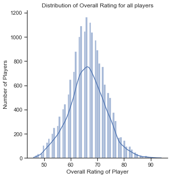

```python
## plotting the distribution of overall rating for players

rating_plot = sns.displot(fifa_df['Overall'], kde = True)
rating_plot.set(xlabel ='Overall Rating of Player',
                ylabel ='Number of Players',
                title ='Distribution of Overall Rating for all players')
plt.figure(1 , figsize = (15 , 6))
plt.show()
```

```python
## description of 'Overall rating' of players
fifa_df.Overall.describe()
```

```
count    18207.000000
mean        66.238699
std          6.908930
min         46.000000
25%         62.000000
50%         66.000000
75%         71.000000
max         94.000000
Name: Overall, dtype: float64
```

# 11. Retrieve the names of top20 players based on the Overall rating.

```python
## Retrieving the names of top  20 players based on Overall rating.

df_overall_sort = fifa_df.copy()
df_overall_sort.sort_values(by='Overall', ascending=False)
print(df_overall_sort[['Name','Overall']].head(20))
```

```
                 Name  Overall
0            L. Messi       94
1   Cristiano Ronaldo       94
2           Neymar Jr       92
3              De Gea       91
4        K. De Bruyne       91
5           E. Hazard       91
6           L. Modrić       91
7           L. Suárez       91
8        Sergio Ramos       91
9            J. Oblak       90
10     R. Lewandowski       90
11           T. Kroos       90
12           D. Godín       90
13        David Silva       90
14           N. Kanté       89
15          P. Dybala       89
16            H. Kane       89
17       A. Griezmann       89
18      M. ter Stegen       89
19        T. Courtois       89
```

# 12. Generate a dataframe which should include all the information of the Top 20 players based on the Overall rating.

```python
#Generating a dataframe with all info for top 20 players of Overall rating.

fifa_top20 = df_overall_sort.head(20)
```

```python
fifa_top20
```

|  | ID | Name | Age | Nationality | Overall | Potential | Club | Value | Wage | Preferred Foot | International Reputation | Weak Foot | Skill Moves | Work Rate | Body Type | Position | Jersey Number | Joined | Loaned From | Contract Valid Until | Height | Weight | Crossing | Finishing | HeadingAccuracy | ShortPassing | Volleys | Dribbling | Curve | … |
| --- | --- | --- | --- | --- | --- | --- | --- | --- | --- | --- | --- | --- | --- | --- | --- | --- | --- | --- | --- | --- | --- | --- | --- | --- | --- | --- | --- | --- | --- | --- |
| 0 | 158023 | L. Messi | 31 | Argentina | 94 | 94 | FC Barcelona | 110500000.0 | 565000.0 | Left | 5.0 | 4.0 | 4.0 | Medium/ Medium | Messi | RF | 10.0 | 2004 | Missing | 2021-01-01 | 5.70 | 159.0 | 84.0 | 95.0 | 70.0 | 90.0 | 86.0 | 97.0 | 93.0 | … |
| 1 | 20801 | Cristiano Ronaldo | 33 | Portugal | 94 | 94 | Juventus | 77000000.0 | 405000.0 | Right | 5.0 | 4.0 | 5.0 | High/ Low | C. Ronaldo | ST | 7.0 | 2018 | Missing | 2022-01-01 | 6.20 | 183.0 | 84.0 | 94.0 | 89.0 | 81.0 | 87.0 | 88.0 | 81.0 | … |
| 2 | 190871 | Neymar Jr | 26 | Brazil | 92 | 93 | Paris Saint-Germain | 118500000.0 | 290000.0 | Right | 5.0 | 5.0 | 5.0 | High/ Medium | Neymar | LW | 10.0 | 2017 | Missing | 2022-01-01 | 5.90 | 150.0 | 79.0 | 87.0 | 62.0 | 84.0 | 84.0 | 96.0 | 88.0 | … |
| 3 | 193080 | De Gea | 27 | Spain | 91 | 93 | Manchester United | 72000000.0 | 260000.0 | Right | 4.0 | 3.0 | 1.0 | Medium/ Medium | Lean | GK | 1.0 | 2011 | Missing | 2020-01-01 | 6.40 | 168.0 | 17.0 | 13.0 | 21.0 | 50.0 | 13.0 | 18.0 | 21.0 | … |
| 4 | 192985 | K. De Bruyne | 27 | Belgium | 91 | 92 | Manchester City | 102000000.0 | 355000.0 | Right | 4.0 | 5.0 | 4.0 | High/ High | Normal | RCM | 7.0 | 2015 | Missing | 2023-01-01 | 5.11 | 154.0 | 93.0 | 82.0 | 55.0 | 92.0 | 82.0 | 86.0 | 85.0 | … |
| 5 | 183277 | E. Hazard | 27 | Belgium | 91 | 91 | Chelsea | 93000000.0 | 340000.0 | Right | 4.0 | 4.0 | 4.0 | High/ Medium | Normal | LF | 10.0 | 2012 | Missing | 2020-01-01 | 5.80 | 163.0 | 81.0 | 84.0 | 61.0 | 89.0 | 80.0 | 95.0 | 83.0 | … |
| 6 | 177003 | L. Modrić | 32 | Croatia | 91 | 91 | Real Madrid | 67000000.0 | 420000.0 | Right | 4.0 | 4.0 | 4.0 | High/ High | Lean | RCM | 10.0 | 2012 | Missing | 2020-01-01 | 5.80 | 146.0 | 86.0 | 72.0 | 55.0 | 93.0 | 76.0 | 90.0 | 85.0 | … |
| 7 | 176580 | L. Suárez | 31 | Uruguay | 91 | 91 | FC Barcelona | 80000000.0 | 455000.0 | Right | 5.0 | 4.0 | 3.0 | High/ Medium | Normal | RS | 9.0 | 2014 | Missing | 2021-01-01 | 6.00 | 190.0 | 77.0 | 93.0 | 77.0 | 82.0 | 88.0 | 87.0 | 86.0 | … |
| 8 | 155862 | Sergio Ramos | 32 | Spain | 91 | 91 | Real Madrid | 51000000.0 | 380000.0 | Right | 4.0 | 3.0 | 3.0 | High/ Medium | Normal | RCB | 15.0 | 2005 | Missing | 2020-01-01 | 6.00 | 181.0 | 66.0 | 60.0 | 91.0 | 78.0 | 66.0 | 63.0 | 74.0 | … |
| 9 | 200389 | J. Oblak | 25 | Slovenia | 90 | 93 | Atlético Madrid | 68000000.0 | 94000.0 | Right | 3.0 | 3.0 | 1.0 | Medium/ Medium | Normal | GK | 1.0 | 2014 | Missing | 2021-01-01 | 6.20 | 192.0 | 13.0 | 11.0 | 15.0 | 29.0 | 13.0 | 12.0 | 13.0 | … |
| 10 | 188545 | R. Lewandowski | 29 | Poland | 90 | 90 | FC Bayern München | 77000000.0 | 205000.0 | Right | 4.0 | 4.0 | 4.0 | High/ Medium | Normal | ST | 9.0 | 2014 | Missing | 2021-01-01 | 6.00 | 176.0 | 62.0 | 91.0 | 85.0 | 83.0 | 89.0 | 85.0 | 77.0 | … |
| 11 | 182521 | T. Kroos | 28 | Germany | 90 | 90 | Real Madrid | 76500000.0 | 355000.0 | Right | 4.0 | 5.0 | 3.0 | Medium/ Medium | Normal | LCM | 8.0 | 2014 | Missing | 2022-01-01 | 6.00 | 168.0 | 88.0 | 76.0 | 54.0 | 92.0 | 82.0 | 81.0 | 86.0 | … |
| 12 | 182493 | D. Godín | 32 | Uruguay | 90 | 90 | Atlético Madrid | 44000000.0 | 125000.0 | Right | 3.0 | 3.0 | 2.0 | Medium/ High | Lean | CB | 10.0 | 2010 | Missing | 2019-01-01 | 6.20 | 172.0 | 55.0 | 42.0 | 92.0 | 79.0 | 47.0 | 53.0 | 49.0 | … |
| 13 | 168542 | David Silva | 32 | Spain | 90 | 90 | Manchester City | 60000000.0 | 285000.0 | Left | 4.0 | 2.0 | 4.0 | High/ Medium | Normal | LCM | 21.0 | 2010 | Missing | 2020-01-01 | 5.80 | 148.0 | 84.0 | 76.0 | 54.0 | 93.0 | 82.0 | 89.0 | 82.0 | … |
| 14 | 215914 | N. Kanté | 27 | France | 89 | 90 | Chelsea | 63000000.0 | 225000.0 | Right | 3.0 | 3.0 | 2.0 | Medium/ High | Lean | LDM | 13.0 | 2016 | Missing | 2023-01-01 | 5.60 | 159.0 | 68.0 | 65.0 | 54.0 | 86.0 | 56.0 | 79.0 | 49.0 | … |
| 15 | 211110 | P. Dybala | 24 | Argentina | 89 | 94 | Juventus | 89000000.0 | 205000.0 | Left | 3.0 | 3.0 | 4.0 | High/ Medium | Normal | LF | 21.0 | 2015 | Missing | 2022-01-01 | 5.10 | 165.0 | 82.0 | 84.0 | 68.0 | 87.0 | 88.0 | 92.0 | 88.0 | … |
| 16 | 202126 | H. Kane | 24 | England | 89 | 91 | Tottenham Hotspur | 83500000.0 | 205000.0 | Right | 3.0 | 4.0 | 3.0 | High/ High | Normal | ST | 9.0 | 2010 | Missing | 2024-01-01 | 6.20 | 196.0 | 75.0 | 94.0 | 85.0 | 80.0 | 84.0 | 80.0 | 78.0 | … |
| 17 | 194765 | A. Griezmann | 27 | France | 89 | 90 | Atlético Madrid | 78000000.0 | 145000.0 | Left | 4.0 | 3.0 | 4.0 | High/ High | Lean | CAM | 7.0 | 2014 | Missing | 2023-01-01 | 5.90 | 161.0 | 82.0 | 90.0 | 84.0 | 83.0 | 87.0 | 88.0 | 84.0 | … |
| 18 | 192448 | M. ter Stegen | 26 | Germany | 89 | 92 | FC Barcelona | 58000000.0 | 240000.0 | Right | 3.0 | 4.0 | 1.0 | Medium/ Medium | Normal | GK | 22.0 | 2014 | Missing | 2022-01-01 | 6.20 | 187.0 | 15.0 | 14.0 | 11.0 | 36.0 | 14.0 | 17.0 | 18.0 | … |
| 19 | 192119 | T. Courtois | 26 | Belgium | 89 | 90 | Real Madrid | 53500000.0 | 240000.0 | Left | 4.0 | 2.0 | 1.0 | Medium/ Medium | Courtois | GK | 1.0 | 2018 | Missing | 2024-01-01 | 6.60 | 212.0 | 14.0 | 14.0 | 13.0 | 33.0 | 12.0 | 13.0 | 19.0 | … |

# 13. What is the average "Age" and "Wage" of these top 20 players? (use the data frame created in the question 11)

```python
avg_age = str(fifa_top20['Age'].mean())
avg_wage = str(fifa_top20['Wage'].mean())

print('Average Age : ' + avg_age + 'Yrs' '\n' 'Average Wage : €' + avg_wage)
```

```
Average Age : 28.3Yrs
Average Wage : €289700.0
```

# 14. Among the top 20 players based on the Overall rating, which player has the highest wage? Display the name of the player with his wage.

```python
top_wage_df = fifa_top20.sort_values(by='Wage', ascending = False)

print(top_wage_df[['Name', 'Wage']].head(1))
```

```
       Name      Wage
0  L. Messi  565000.0
```

# 15. Generate a dataframe which should include the "Player name", "Club Name", "Wage", and 'Overall rating'.

#### - i) find the average Overall rating for each club.

```python
temp_df = pd.DataFrame.copy(fifa_df[['Name','Club','Wage','Overall']])
temp_df.head(5)
```

|  | Name | Club | Wage | Overall |
| --- | --- | --- | --- | --- |
| 0 | L. Messi | FC Barcelona | 565000.0 | 94 |
| 1 | Cristiano Ronaldo | Juventus | 405000.0 | 94 |
| 2 | Neymar Jr | Paris Saint-Germain | 290000.0 | 92 |
| 3 | De Gea | Manchester United | 260000.0 | 91 |
| 4 | K. De Bruyne | Manchester City | 355000.0 | 91 |

```python
avg_club_rat = temp_df.groupby(['Club'])[['Overall']].mean()
avg_club_rat
```

| Club | Overall |
| --- | --- |
| SSV Jahn Regensburg | 65.586207 |
| 1. FC Heidenheim 1846 | 65.750000 |
| 1. FC Kaiserslautern | 63.384615 |
| 1. FC Köln | 70.785714 |
| 1. FC Magdeburg | 65.615385 |
| ... | ... |
| Zagłębie Sosnowiec | 60.760000 |
| Çaykur Rizespor | 66.900000 |
| Örebro SK | 60.481481 |
| Östersunds FK | 63.545455 |
| Śląsk Wrocław | 62.200000 |

652 rows × 1 columns

#### - ii) Display the average overall rating of Top10 Clubs using a plot

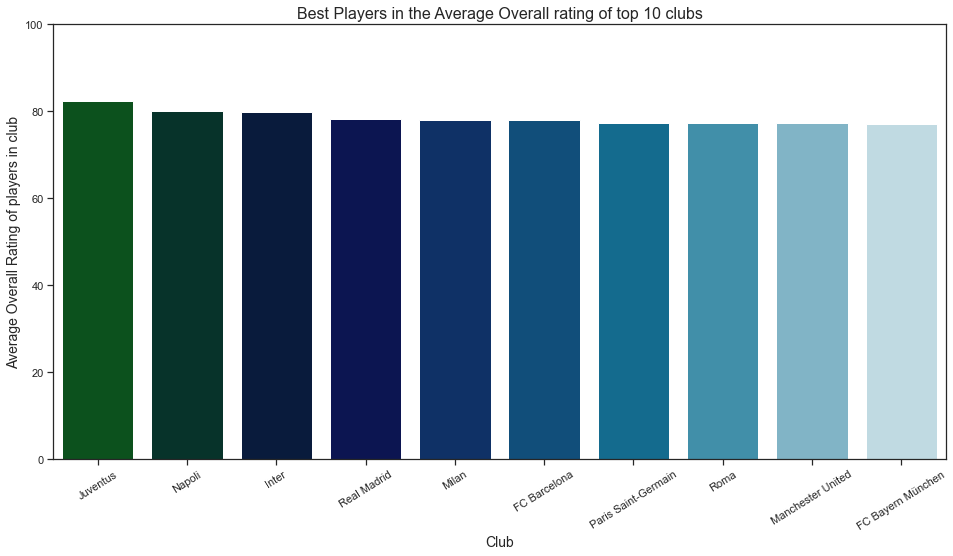

```
                       overall                 club
Juventus             82.280000             Juventus
Napoli               80.000000               Napoli
Inter                79.750000                Inter
Real Madrid          78.242424          Real Madrid
Milan                78.074074                Milan
FC Barcelona         78.030303         FC Barcelona
Paris Saint-Germain  77.433333  Paris Saint-Germain
Roma                 77.423077                 Roma
Manchester United    77.242424    Manchester United
FC Bayern München    77.000000    FC Bayern München
```

```python
top_club = {}
for club in temp_df['Club'].unique():
    overall_rating = temp_df['Overall'][temp_df['Club'] == club].mean()
    top_club[club] = overall_rating

best_club = pd.DataFrame.from_dict(top_club, orient = 'index', columns = ['overall'])
best_club['club'] = best_club.index
best_club = best_club.sort_values(by = 'overall', ascending =  False)

plt.figure(1 , figsize = (16 , 8))
sns.barplot(x ='club', y ='overall', data = best_club.head(10), palette = 'ocean')
plt.xticks(rotation = 32)

plt.xlabel('Club', fontsize = 14)
plt.ylabel('Average Overall Rating of players in club', fontsize = 14)
plt.title('Best Players in the Average Overall rating of top 10 clubs', fontsize = 16)
plt.ylim(0 , 100)

plt.show()
print(best_club.head(10))
```

# 16. What is the relationship between age and individual potential of the player? Visualize the relationship with appropriate plot and Comment on the same.

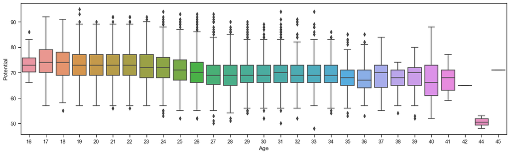

```python
## Plotting relationship between age and potential of players

plt.figure(figsize=(18,5))
sns.boxplot(fifa_df['Age'],fifa_df['Potential'])
plt.show()
```

- Players show peak potential in their 17 and their maximum potential at 19 as it can be inferred if we observe the above plot.
- After that there is a slight decrease in their potential and it remains with slight fluctuations until theri 34.
- After 34 players shows varying potential as their age increases based on some of their cases.

# 17. Which features directly contribute to the wages of the players? support your answer with a plot and a metric. (hint: use potential, Overall, value, international reputation, and Release Clause)

```python
## generating dataframe

rel_df = pd.DataFrame.copy(fifa_df[['Wage','Potential','Overall','Value','International Reputation','Release Clause']])
rel_df
```

|  | Wage | Potential | Overall | Value | International Reputation | Release Clause |
| --- | --- | --- | --- | --- | --- | --- |
| 0 | 565000.0 | 94 | 94 | 110500000.0 | 5.0 | 226500000.0 |
| 1 | 405000.0 | 94 | 94 | 77000000.0 | 5.0 | 127100000.0 |
| 2 | 290000.0 | 93 | 92 | 118500000.0 | 5.0 | 228100000.0 |
| 3 | 260000.0 | 93 | 91 | 72000000.0 | 4.0 | 138600000.0 |
| 4 | 355000.0 | 92 | 91 | 102000000.0 | 4.0 | 196400000.0 |
| ... | ... | ... | ... | ... | ... | ... |
| 18202 | 1000.0 | 65 | 47 | 60000.0 | 1.0 | 143000000.0 |
| 18203 | 1000.0 | 63 | 47 | 60000.0 | 1.0 | 113000000.0 |
| 18204 | 1000.0 | 67 | 47 | 60000.0 | 1.0 | 165000000.0 |
| 18205 | 1000.0 | 66 | 47 | 60000.0 | 1.0 | 143000000.0 |
| 18206 | 1000.0 | 66 | 46 | 60000.0 | 1.0 | 165000000.0 |

18207 rows × 6 columns

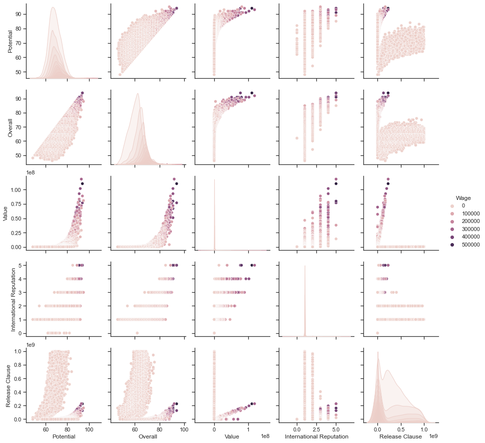

```python
## plot of relation with various features with column 'Wage'

plt.figure(1 , figsize = (12,8))
plotgrid = sns.pairplot(rel_df, hue = 'Wage', diag_kind = 'kde')

plt.show()
```

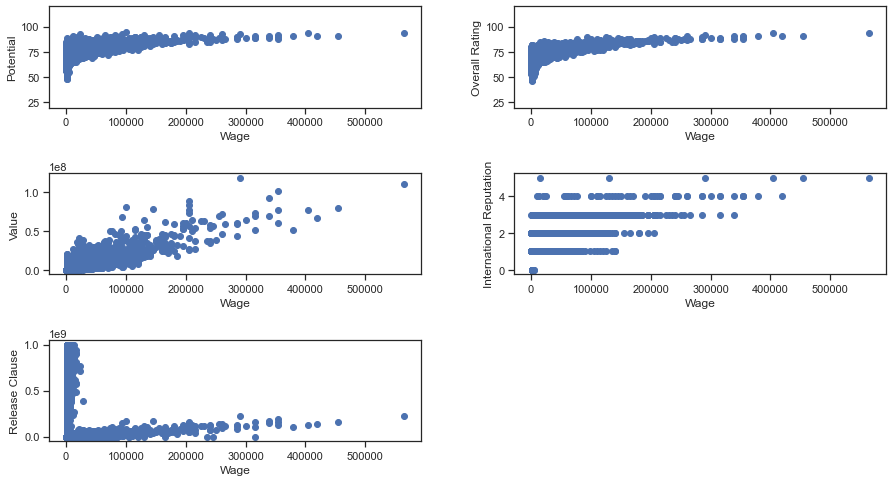

```python
rows = 3
columns = 2
plt.figure(figsize = (15, 8))
grid = plt.GridSpec(rows, columns, wspace = .25, hspace = .65)

plt.subplot(grid[0])
plt.scatter(rel_df['Wage'], rel_df['Potential'])
plt.xlabel('Wage')
plt.ylabel('Potential')
plt.ylim(20, 120)

plt.subplot(grid[1])
plt.scatter(rel_df['Wage'], rel_df['Overall'])
plt.xlabel('Wage')
plt.ylabel('Overall Rating')
plt.ylim(20, 120)

plt.subplot(grid[2])
plt.scatter(rel_df['Wage'], rel_df['Value'])
plt.xlabel('Wage')
plt.ylabel('Value')

plt.subplot(grid[3])
plt.scatter(rel_df['Wage'], rel_df['International Reputation'])
plt.xlabel('Wage')
plt.ylabel('International Reputation')

plt.subplot(grid[4])
plt.scatter(rel_df['Wage'], rel_df['Release Clause'])
plt.xlabel('Wage')
plt.ylabel('Release Clause')
```

# 18. Find the position in the pitch where the maximum number of players play and the position where the minimum number of players play? Display it using a plot.

```python
pos_df = fifa_df.groupby('Position')['Position'].count().sort_values(ascending=False)
pos_df
```

```
Position
ST         2152
GK         2025
CB         1778
CM         1394
LB         1322
RB         1291
RM         1124
LM         1095
CAM         958
CDM         948
RCB         662
LCB         648
LCM         395
RCM         391
LW          381
RW          370
RDM         248
LDM         243
LS          207
RS          203
RWB          87
LWB          78
CF           74
Missing      60
RAM          21
LAM          21
RF           16
LF           15
Name: Position, dtype: int64
```

```python
list = pos_df.index.tolist()

print('Pitch position of Max Number of Player : ', list[0])
print('Pitch position of Min Number of Player : ',list[-1])
```

```
Pitch position of Max Number of Player :  ST
Pitch position of Min Number of Player :  LF
```

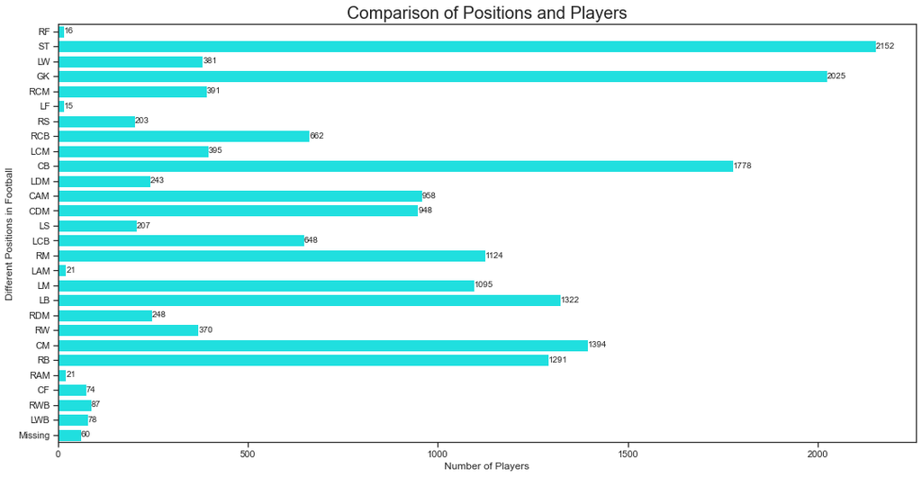

```python
## count plot for players based on position

plt.figure(figsize = (18, 9))
pos_df = sns.countplot(y = fifa_df['Position'], color = 'cyan')

pos_df.set_xlabel(xlabel = 'Number of Players', fontsize = 12)
pos_df.set_ylabel(ylabel = 'Different Positions in Football', fontsize = 12)
pos_df.set_title(label = 'Comparison of Positions and Players', fontsize = 20)

pos_df.bar_label(pos_df.containers[0], fontsize = 10)

plt.show()
```

# 19. How many players are from the club 'Juventus' and the wage is greater than 200K? Display all the information of such players.

```python
drilldown_val = np.where((fifa_df['Club'] == 'Juventus') & (fifa_df['Wage'] > 200000))
filter_df = fifa_df.loc[drilldown_val]

print(str(filter_df['Club'].count()) + " players in Juventus club has Wages > 200000 ")
display(filter_df)
```

```
3 players in Juventus club has Wages > 200000
```

|  | ID | Name | Age | Nationality | Overall | Potential | Club | Value | Wage | Preferred Foot | International Reputation | Weak Foot | Skill Moves | Work Rate | Body Type | Position | Jersey Number | Joined | Loaned From | Contract Valid Until | Height | Weight | Crossing | Finishing | HeadingAccuracy | ShortPassing | Volleys | Dribbling | Curve | … |
| --- | --- | --- | --- | --- | --- | --- | --- | --- | --- | --- | --- | --- | --- | --- | --- | --- | --- | --- | --- | --- | --- | --- | --- | --- | --- | --- | --- | --- | --- | --- |
| 1 | 20801 | Cristiano Ronaldo | 33 | Portugal | 94 | 94 | Juventus | 77000000.0 | 405000.0 | Right | 5.0 | 4.0 | 5.0 | High/ Low | C. Ronaldo | ST | 7.0 | 2018 | Missing | 2022-01-01 | 6.2 | 183.0 | 84.0 | 94.0 | 89.0 | 81.0 | 87.0 | 88.0 | 81.0 | … |
| 15 | 211110 | P. Dybala | 24 | Argentina | 89 | 94 | Juventus | 89000000.0 | 205000.0 | Left | 3.0 | 3.0 | 4.0 | High/ Medium | Normal | LF | 21.0 | 2015 | Missing | 2022-01-01 | 5.1 | 165.0 | 82.0 | 84.0 | 68.0 | 87.0 | 88.0 | 92.0 | 88.0 | … |
| 24 | 138956 | G. Chiellini | 33 | Italy | 89 | 89 | Juventus | 27000000.0 | 215000.0 | Left | 4.0 | 3.0 | 2.0 | Medium/ High | Normal | LCB | 3.0 | 2005 | Missing | 2020-01-01 | 6.2 | 187.0 | 58.0 | 33.0 | 83.0 | 59.0 | 45.0 | 58.0 | 60.0 | … |

# 20. Generate a data frame containing top 5 players by Overall rating for each unique position.

```python
df_top5_unique_pos = fifa_df.groupby(by = ['Position']).apply(lambda x: x.sort_values('Overall', ascending = False).head(5))
display(df_top5_unique_pos)
```

| Position |  | ID | Name | Age | Nationality | Overall | Potential | Club | Value | Wage | Preferred Foot | International Reputation | Weak Foot | Skill Moves | Work Rate | Body Type | Position | Jersey Number | Joined | Loaned From | Contract Valid Until | Height | Weight | Crossing | Finishing | HeadingAccuracy | ShortPassing | Volleys | Dribbling | … |
| --- | --- | --- | --- | --- | --- | --- | --- | --- | --- | --- | --- | --- | --- | --- | --- | --- | --- | --- | --- | --- | --- | --- | --- | --- | --- | --- | --- | --- | --- | --- |
| CAM | 17 | 194765 | A. Griezmann | 27 | France | 89 | 90 | Atlético Madrid | 78000000.0 | 145000.0 | Left | 4.0 | 3.0 | 4.0 | High/ High | Lean | CAM | 7.0 | 2014 | Missing | 2023-01-01 | 5.90 | 161.0 | 82.0 | 90.0 | 84.0 | 83.0 | 87.0 | 88.0 | … |
|  | 31 | 190460 | C. Eriksen | 26 | Denmark | 88 | 91 | Tottenham Hotspur | 73500000.0 | 205000.0 | Right | 3.0 | 5.0 | 4.0 | High/ Medium | Lean | CAM | 10.0 | 2013 | Missing | 2020-01-01 | 5.11 | 168.0 | 88.0 | 80.0 | 52.0 | 91.0 | 77.0 | 84.0 | … |
|  | 61 | 201942 | Roberto Firmino | 26 | Brazil | 86 | 87 | Liverpool | 53000000.0 | 195000.0 | Right | 3.0 | 4.0 | 4.0 | High/ High | Lean | CAM | 9.0 | 2015 | Missing | 2023-01-01 | 5.11 | 168.0 | 72.0 | 87.0 | 77.0 | 86.0 | 81.0 | 87.0 | … |
|  | 66 | 189596 | T. Müller | 28 | Germany | 86 | 86 | FC Bayern München | 45000000.0 | 135000.0 | Right | 4.0 | 4.0 | 3.0 | High/ High | Lean | CAM | 13.0 | 2008 | Missing | 2021-01-01 | 6.10 | 165.0 | 79.0 | 87.0 | 82.0 | 83.0 | 84.0 | 75.0 | … |
|  | 74 | 176635 | M. Özil | 29 | Germany | 86 | 86 | Arsenal | 43500000.0 | 190000.0 | Left | 4.0 | 2.0 | 4.0 | Medium/ Low | Lean | CAM | 10.0 | 2013 | Missing | 2021-01-01 | 5.11 | 168.0 | 83.0 | 73.0 | 54.0 | 89.0 | 80.0 | 84.0 | … |
| ... | ... | ... | ... | ... | ... | ... | ... | ... | ... | ... | ... | ... | ... | ... | ... | ... | ... | ... | ... | ... | ... | ... | ... | ... | ... | ... | ... | ... | ... | … |
| ST | 1 | 20801 | Cristiano Ronaldo | 33 | Portugal | 94 | 94 | Juventus | 77000000.0 | 405000.0 | Right | 5.0 | 4.0 | 5.0 | High/ Low | C. Ronaldo | ST | 7.0 | 2018 | Missing | 2022-01-01 | 6.20 | 183.0 | 84.0 | 94.0 | 89.0 | 81.0 | 87.0 | 88.0 | … |
|  | 10 | 188545 | R. Lewandowski | 29 | Poland | 90 | 90 | FC Bayern München | 77000000.0 | 205000.0 | Right | 4.0 | 4.0 | 4.0 | High/ Medium | Normal | ST | 9.0 | 2014 | Missing | 2021-01-01 | 6.00 | 176.0 | 62.0 | 91.0 | 85.0 | 83.0 | 89.0 | 85.0 | … |
|  | 16 | 202126 | H. Kane | 24 | England | 89 | 91 | Tottenham Hotspur | 83500000.0 | 205000.0 | Right | 3.0 | 4.0 | 3.0 | High/ High | Normal | ST | 9.0 | 2010 | Missing | 2024-01-01 | 6.20 | 196.0 | 75.0 | 94.0 | 85.0 | 80.0 | 84.0 | 80.0 | … |
|  | 23 | 153079 | S. Agüero | 30 | Argentina | 89 | 89 | Manchester City | 64500000.0 | 300000.0 | Right | 4.0 | 4.0 | 4.0 | High/ Medium | Stocky | ST | 10.0 | 2011 | Missing | 2021-01-01 | 5.80 | 154.0 | 70.0 | 93.0 | 77.0 | 81.0 | 85.0 | 89.0 | … |
|  | 36 | 173731 | G. Bale | 28 | Wales | 88 | 88 | Real Madrid | 60000000.0 | 355000.0 | Left | 4.0 | 3.0 | 4.0 | High/ Medium | Lean | ST | 11.0 | 2013 | Missing | 2022-01-01 | 6.10 | 181.0 | 87.0 | 86.0 | 84.0 | 85.0 | 85.0 | 87.0 | … |

140 rows × 57 columns

# 21. What is the average wage one can expect to pay for the top 5 players in every position?

```python
avg_wage= df_top5_unique_pos['Wage'].groupby('Position').apply(np.mean)
print('Average Wage of top 5 players based on Overall rating for every Position : ')
print(avg_wage)
```

```
Average Wage of top 5 players based on Overall rating for every Position :
Position
CAM        174000.0
CB         139600.0
CDM        217000.0
CF          47400.0
CM         130600.0
GK         192800.0
LAM         81600.0
LB         177200.0
LCB        162000.0
LCM        184400.0
LDM        126600.0
LF         121200.0
LM         164600.0
LS         130200.0
LW         261000.0
LWB         34200.0
Missing         0.0
RAM         45400.0
RB         155400.0
RCB        231000.0
RCM        240800.0
RDM        105000.0
RF         148000.0
RM         131400.0
RS         132200.0
RW         202000.0
RWB         44200.0
ST         294000.0
Name: Wage, dtype: float64
```

- Highest average wage for the players is €294K who holds the position'ST'.
- Lowest average wage for the players is €34.2k who holds the position'LWB'(if we exclude the 'Missing' position).